# Linear regression

Now, we will experiment with different combinations of predictors, including possible transformations and interactions, for each of the methods. Report the variables, method, and associated confusion matrix that appears to provide the best results on the held out data. Note that you should also experiment with values for K in the KNN classifier.

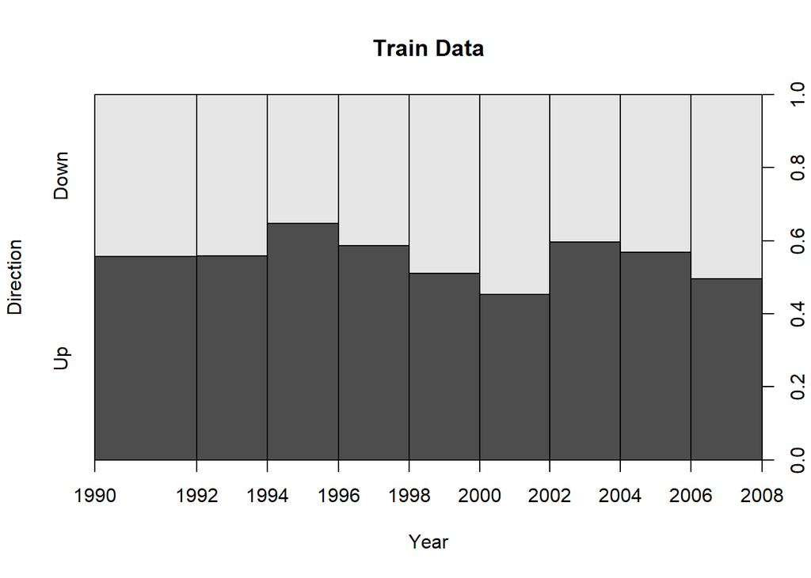

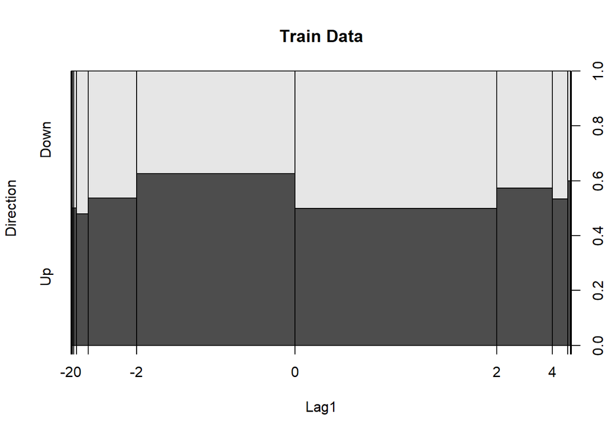

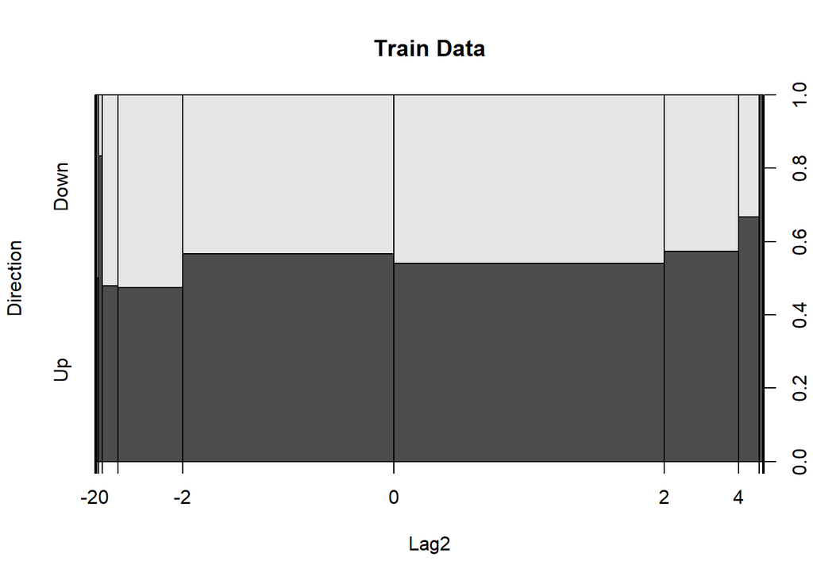

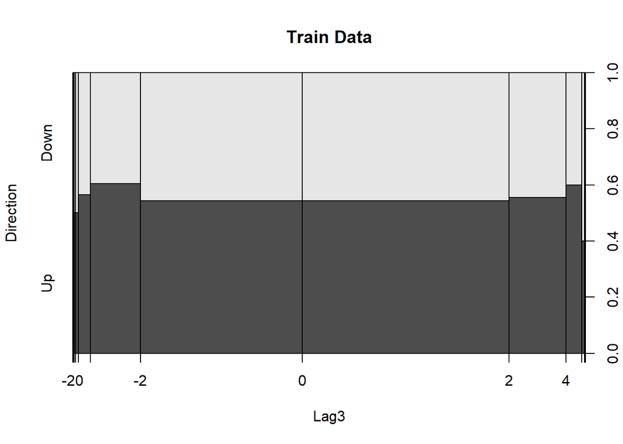

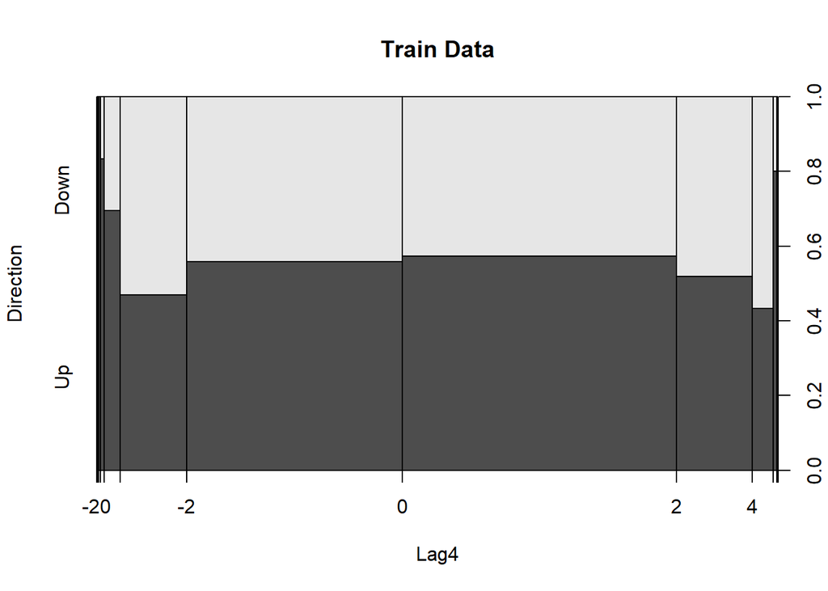

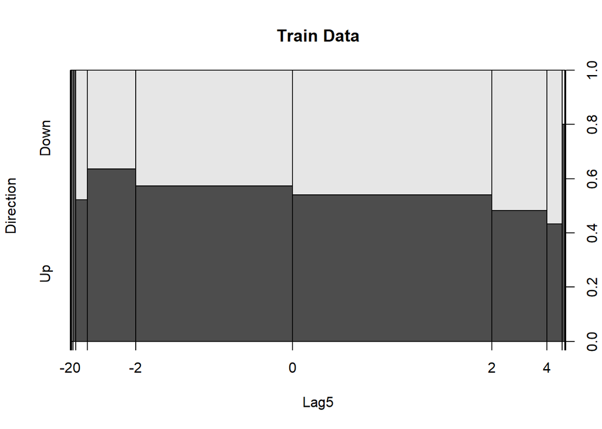

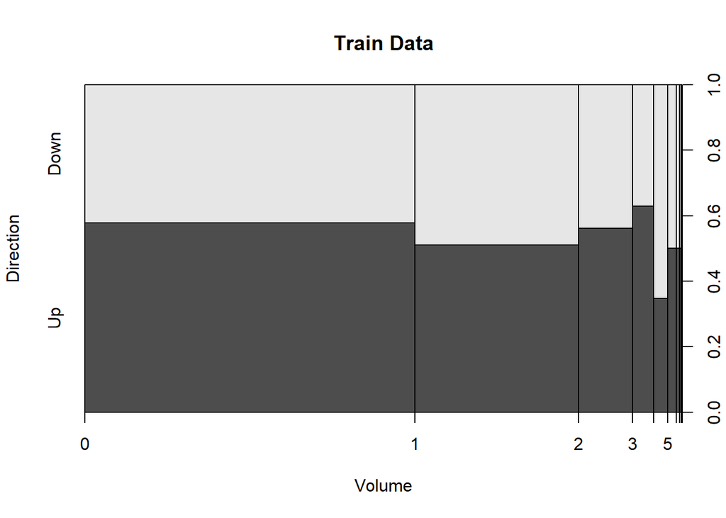

```r
## Since Lag1 and lag2 had the lowest p-vales, so trying with both
for(i in 1:7){
  plot(train$Direction~train[,i],xlab=names(train)[i],ylab="Direction",
       main="Train Data")
}
```

```r
## trying with different combinations
formula1=Direction~Lag1
formula2=Direction~Lag2
formula3=Direction~Lag1+Lag2
formula4=Direction~Lag1+Lag2+Lag1*Lag2
formula5=Direction~Lag2+Lag5
formula6=Direction~Lag2+Lag5+Volume
formula7=Direction~Lag2+Volume
formula8=Direction~Lag2+I(Lag2^2)


## All the LDA mdoels
ldamodel1=lda(formula1,data=train)
ldamodel2=lda(formula2,data=train)
ldamodel3=lda(formula3,data=train)
ldamodel4=lda(formula4,data=train)
ldamodel5=lda(formula5,data=train)
ldamodel6=lda(formula6,data=train)
ldamodel7=lda(formula7,data=train)
ldamodel8=lda(formula8,data=train)
## Results
computeLDA(ldamodel1,test)
```

```
## Confusion matrix:
## preds  Down Up
##   Down    4  6
##   Up     39 55
## Model Accuracy (Percentage):[1] 56.73
## True Positive Rate, TPR (percentage):[1] 90.16
## False Postive Rate, FPR (percentage):[1] 90.7
```

```r
computeLDA(ldamodel2,test)
```

```
## Confusion matrix:
## preds  Down Up
##   Down    9  5
##   Up     34 56
## Model Accuracy (Percentage):[1] 62.5
## True Positive Rate, TPR (percentage):[1] 91.8
## False Postive Rate, FPR (percentage):[1] 79.07
```

```r
computeLDA(ldamodel3,test)
```

```
## Confusion matrix:
## preds  Down Up
##   Down    7  8
##   Up     36 53
## Model Accuracy (Percentage):[1] 57.69
## True Positive Rate, TPR (percentage):[1] 86.89
## False Postive Rate, FPR (percentage):[1] 83.72
```

```r
computeLDA(ldamodel4,test)
```

```
## Confusion matrix:
## preds  Down Up
##   Down    7  8
##   Up     36 53
## Model Accuracy (Percentage):[1] 57.69
## True Positive Rate, TPR (percentage):[1] 86.89
## False Postive Rate, FPR (percentage):[1] 83.72
```

```r
computeLDA(ldamodel5,test)
```

```
## Confusion matrix:
## preds  Down Up
##   Down    6  5
##   Up     37 56
## Model Accuracy (Percentage):[1] 59.62
## True Positive Rate, TPR (percentage):[1] 91.8
## False Postive Rate, FPR (percentage):[1] 86.05
```

```r
computeLDA(ldamodel6,test)
```

```
## Confusion matrix:
## preds  Down Up
##   Down   23 33
##   Up     20 28
## Model Accuracy (Percentage):[1] 49.04
## True Positive Rate, TPR (percentage):[1] 45.9
## False Postive Rate, FPR (percentage):[1] 46.51
```

```r
computeLDA(ldamodel7,test)
```

```
## Confusion matrix:
## preds  Down Up
##   Down   20 25
##   Up     23 36
## Model Accuracy (Percentage):[1] 53.85
## True Positive Rate, TPR (percentage):[1] 59.02
## False Postive Rate, FPR (percentage):[1] 53.49
```

```r
computeLDA(ldamodel8,test)
```

```
## Confusion matrix:
## preds  Down Up
##   Down    7  4
##   Up     36 57
## Model Accuracy (Percentage):[1] 61.54
## True Positive Rate, TPR (percentage):[1] 93.44
## False Postive Rate, FPR (percentage):[1] 83.72
```

```r
## All the QDA mdoels
qdamodel1=qda(formula1,data=train)
qdamodel2=qda(formula2,data=train)
qdamodel3=qda(formula3,data=train)
qdamodel4=qda(formula4,data=train)
qdamodel5=qda(formula5,data=train)
qdamodel6=qda(formula6,data=train)
qdamodel7=qda(formula7,data=train)
qdamodel8=qda(formula8,data=train)
## Results (we can use the same function here)
computeLDA(qdamodel1,test)
```

```
## Confusion matrix:
## preds  Down Up
##   Down    0  0
##   Up     43 61
## Model Accuracy (Percentage):[1] 58.65
## True Positive Rate, TPR (percentage):[1] 100
## False Postive Rate, FPR (percentage):[1] 100
```

```r
computeLDA(qdamodel2,test)
```

```
## Confusion matrix:
## preds  Down Up
##   Down    0  0
##   Up     43 61
## Model Accuracy (Percentage):[1] 58.65
## True Positive Rate, TPR (percentage):[1] 100
## False Postive Rate, FPR (percentage):[1] 100
```

```r
computeLDA(qdamodel3,test)
```

```
## Confusion matrix:
## preds  Down Up
##   Down    7 10
##   Up     36 51
## Model Accuracy (Percentage):[1] 55.77
## True Positive Rate, TPR (percentage):[1] 83.61
## False Postive Rate, FPR (percentage):[1] 83.72
```

```r
computeLDA(qdamodel4,test)
```

```
## Confusion matrix:
## preds  Down Up
##   Down   23 36
##   Up     20 25
## Model Accuracy (Percentage):[1] 46.15
## True Positive Rate, TPR (percentage):[1] 40.98
## False Postive Rate, FPR (percentage):[1] 46.51
```

```r
computeLDA(qdamodel5,test)
```

```
## Confusion matrix:
## preds  Down Up
##   Down    3 11
##   Up     40 50
## Model Accuracy (Percentage):[1] 50.96
## True Positive Rate, TPR (percentage):[1] 81.97
## False Postive Rate, FPR (percentage):[1] 93.02
```

```r
computeLDA(qdamodel6,test)
```

```
## Confusion matrix:
## preds  Down Up
##   Down   31 42
##   Up     12 19
## Model Accuracy (Percentage):[1] 48.08
## True Positive Rate, TPR (percentage):[1] 31.15
## False Postive Rate, FPR (percentage):[1] 27.91
```

```r
computeLDA(qdamodel7,test)
```

```
## Confusion matrix:
## preds  Down Up
##   Down   32 44
##   Up     11 17
## Model Accuracy (Percentage):[1] 47.12
## True Positive Rate, TPR (percentage):[1] 27.87
## False Postive Rate, FPR (percentage):[1] 25.58
```

```r
computeLDA(qdamodel8,test)
```

```
## Confusion matrix:
## preds  Down Up
##   Down    7  3
##   Up     36 58
## Model Accuracy (Percentage):[1] 62.5
## True Positive Rate, TPR (percentage):[1] 95.08
## False Postive Rate, FPR (percentage):[1] 83.72
```

```r
## KNN
i=1
ks=c(1,3,5,10,20,50,100)
for(i in ks){
  print("########################################")
  print(paste0("K = ",i))
  computeKNN(knn(knn_train, knn_test, cl=train_class, k = i), test$Direction)
  print("########################################")
}
```

```
## [1] "########################################"
## [1] "K = 1"
## [1] "Confusion Matrix:"
##       trues
## model  Down Up
##   Down   21 29
##   Up     22 32
## [1] "Model Accuracy (Percentage):"
## [1] 50.96
## [1] "True Positive Rate, TPR (percentage):"
## [1] 52.46
## [1] "False Postive Rate, FPR (percentage):"
## [1] 51.16
## [1] "########################################"
## [1] "########################################"
```

[output cut: 83 more lines]

Different combination of predictors with possible transformations and interactions were done. LDA and QDA model and associated confusion matrix was developed, and finally K in KNN classifier was done. The output is shown above with all combinations.

Next, we will perform LDA on the training data in order to predict mpg01 using the variables that seemed most associated with mpg01. We will then calculate the the test error of the model obtained.

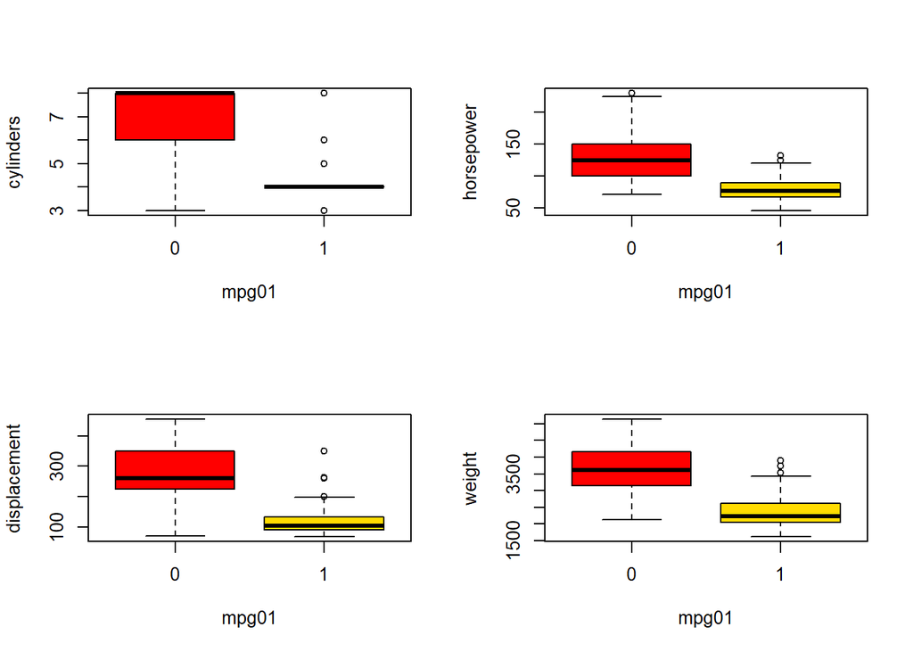

```r
data(Auto)
mpg01=rep(NA,dim(Auto)[1])
med=median(Auto$mpg)
mpg01=ifelse(Auto$mpg<med,0,1)
df=as.data.frame(cbind(Auto, mpg01))

k=c(2,3,4,5,6,7,8) ## taking just the relevant variables
layout(matrix(1:4,nrow = 2))
for(i in k){
  boxplot(df[,i]~df$mpg01,col=rainbow(7),xlab="mpg01",ylab=names(df)[i])
}
```

[figure not shown]

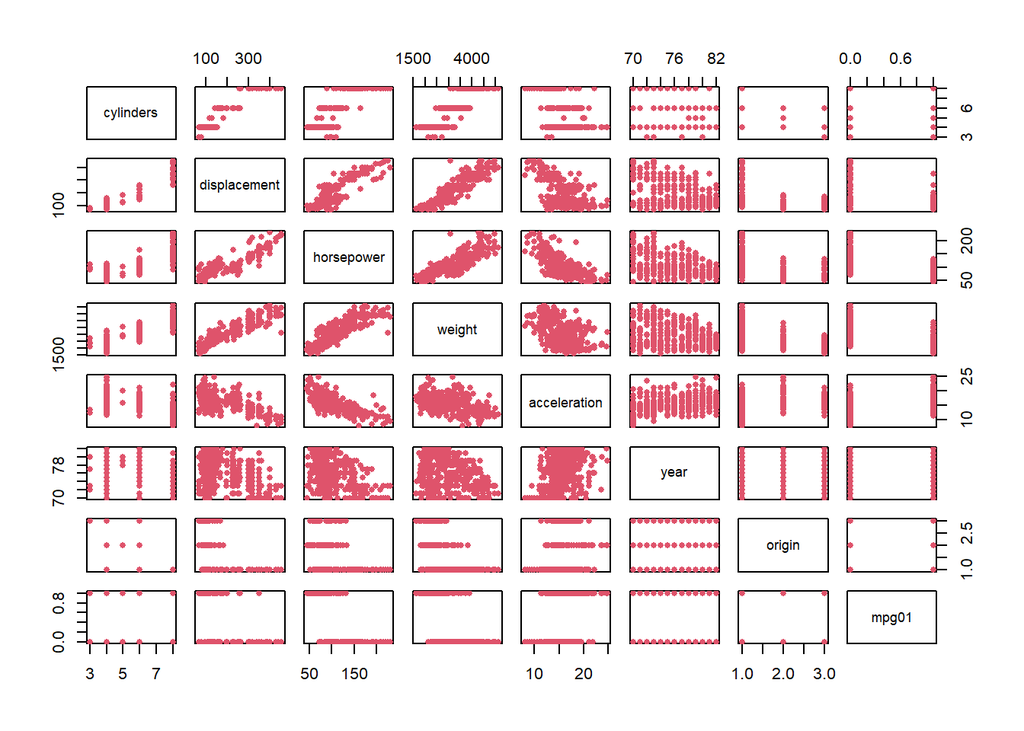

```r
newdf=df[,c(2,3,4,5,6,7,8,10)] ## mpg and names dropped
plot(newdf,pch=16,cex=0.8,col=2)
```

[output not shown]

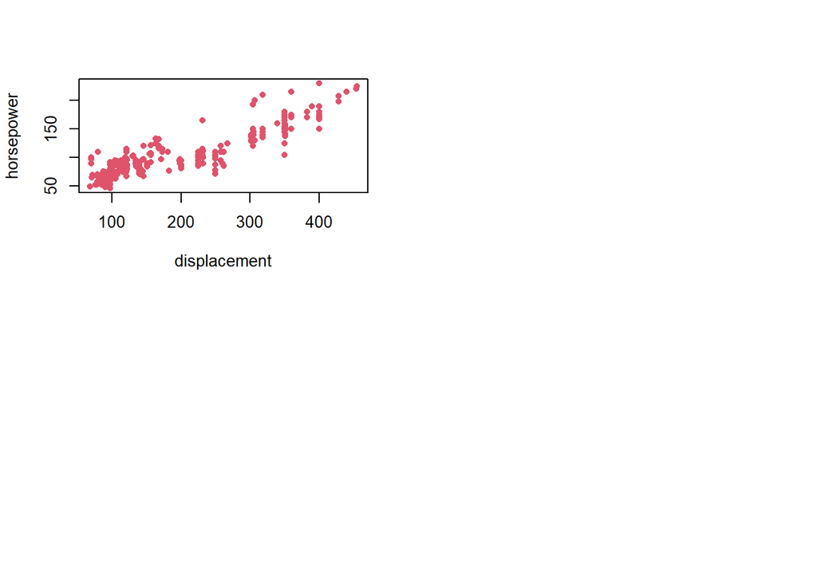

```r
plot(horsepower~displacement,Auto,pch=16,cex=0.8,col=2)


lowmpg=subset(newdf,mpg01==0)
highmpg=subset(newdf,mpg01==1)
set.seed(1235)
index1=sample((1:dim(lowmpg)[1]),size=round(0.5*dim(lowmpg)[1]),replace=F)
index2=sample((1:dim(highmpg)[1]),size=round(0.5*dim(highmpg)[1]),replace=F)
train1=lowmpg[index1,];   train2=highmpg[index2,]
test1=lowmpg[-index1,];   test2=highmpg[-index2,]
autotrain=rbind(train1,train2)
autotest=rbind(test1,test2)


auto_formula=mpg01~cylinders+horsepower+acceleration+origin+displacement+weight+year
auto_model_lda=lda(auto_formula,data=autotrain)

computeForAutoDA=function(model,test){
  trues=test$mpg01
  preds=(predict(model,newdata=test,type="response"))$class
  con=table(preds,trues)
  print("Confusion Matrix:")
  print(con)
  print("Model Accuracy (Percentage):")
  print(round((con[1,1]+con[2,2])/sum(con)*100,2))
  print("True Positive Rate, TPR (percentage):")
  print(round(con[2,2]/(con[2,2]+con[1,2])*100,2))
  print("False Postive Rate, FPR (percentage):")
  spec=con[1,1]/(con[1,1]+con[2,1])*100
  print(round((100-spec),2))
}
computeForAutoDA(auto_model_lda,autotest)
```

Now we will perform QDA on the training data in order to predict mpg01 using the variables that seemed most associated with mpg01. We will then calculate the the test error of the model obtained.

```r
auto_model_qda=qda(auto_formula,data=autotrain)
computeForAutoDA(auto_model_qda,autotest)
```

```
## [1] "Confusion Matrix:"
##      trues
## preds  0  1
##     0 84  4
##     1 14 94
## [1] "Model Accuracy (Percentage):"
## [1] 90.82
## [1] "True Positive Rate, TPR (percentage):"
## [1] 95.92
## [1] "False Postive Rate, FPR (percentage):"
## [1] 14.29
```

Next, we will perform KNN on the training data, with several values of K, in order to predict mpg01. Use only the variables that seemed most associated with mpg01. We will then calculate the test errors, and also see which value of $K$ seems to perform the best on this data set.

```r
library(class)

sel.variables <- which(names(autotrain)%in%c("mpg01", "displacement", "horsepower", "weight", "acceleration", "year", "cylinders", "origin"))

set.seed(1)
accuracies <- data.frame("k"=1:10, acc=NA)
for(k in 1:10){
  knn.pred <- knn(train=autotrain[, sel.variables], test=autotest[, sel.variables], cl=autotrain$mpg01, k=k)

  # test-error
  accuracies$acc[k]= round(sum(knn.pred!=autotest$mpg01)/nrow(autotest)*100,2)
}

accuracies
```

```
##     k   acc
## 1   1 10.20
## 2   2 12.24
## 3   3 11.22
## 4   4 13.27
## 5   5 11.73
## 6   6 12.24
## 7   7  9.69
## 8   8 11.73
## 9   9 11.73
## 10 10 10.71
```

We we will explore this [website](https://archive.ics.uci.edu/ml/datasets.html;%20https://archive.ics.uci.edu/ml/) that contains open datasets that are used in machine learning.

We will explore the `iris` dataset available on this website [website](http://archive.ics.uci.edu/ml/machine-learning-databases/iris/iris.data). It is one the most popular datasets in data science and have been widely used in pattern recognition literature. It is a small dataset with 150 samples, 3 categories of species and 4 features with the sepal length, sepal width, petal length and petal width (in cm). The classification problem in this dataset could be about predicting whether the given flower comes from which particular species or belongs to which species. This classification problem can be solved by developing a model which could be used to predict the flower by first training our model with the features and the labels.

We will try to analyze this data using the KNN or k-nearest neighbors. We will first read our data and check some basic statistics:

```r
# Read in `iris` data
iris <- read.csv(url("http://archive.ics.uci.edu/ml/machine-learning-databases/iris/iris.data"), header = FALSE)

str(iris)
```

```
## 'data.frame':    150 obs. of  5 variables:
##  $ V1: num  5.1 4.9 4.7 4.6 5 5.4 4.6 5 4.4 4.9 ...
##  $ V2: num  3.5 3 3.2 3.1 3.6 3.9 3.4 3.4 2.9 3.1 ...
##  $ V3: num  1.4 1.4 1.3 1.5 1.4 1.7 1.4 1.5 1.4 1.5 ...
##  $ V4: num  0.2 0.2 0.2 0.2 0.2 0.4 0.3 0.2 0.2 0.1 ...
##  $ V5: chr  "Iris-setosa" "Iris-setosa" "Iris-setosa" "Iris-setosa" ...
```

```r
# Add column names
names(iris) <- c("Sepal.Length", "Sepal.Width", "Petal.Length", "Petal.Width", "Species")


# Division of `Species`
table(iris$Species)
```

```
##
##     Iris-setosa Iris-versicolor  Iris-virginica
##              50              50              50
```

```r
# Percentual division of `Species`
round(prop.table(table(iris$Species)) * 100, digits = 1)
```

```
##
##     Iris-setosa Iris-versicolor  Iris-virginica
##            33.3            33.3            33.3
```

```r
# Check the result
# iris
head(iris)
```

```
##   Sepal.Length Sepal.Width Petal.Length Petal.Width     Species
## 1          5.1         3.5          1.4         0.2 Iris-setosa
## 2          4.9         3.0          1.4         0.2 Iris-setosa
## 3          4.7         3.2          1.3         0.2 Iris-setosa
## 4          4.6         3.1          1.5         0.2 Iris-setosa
## 5          5.0         3.6          1.4         0.2 Iris-setosa
## 6          5.4         3.9          1.7         0.4 Iris-setosa
```

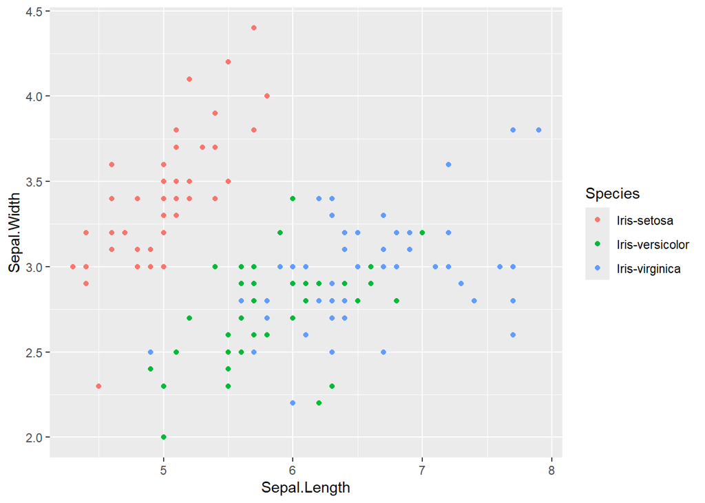

```r
library(ggplot2)
# Iris scatter plot
ggplot(iris, aes(x=Sepal.Length, y=Sepal.Width, col = Species)) +
  geom_point()
```

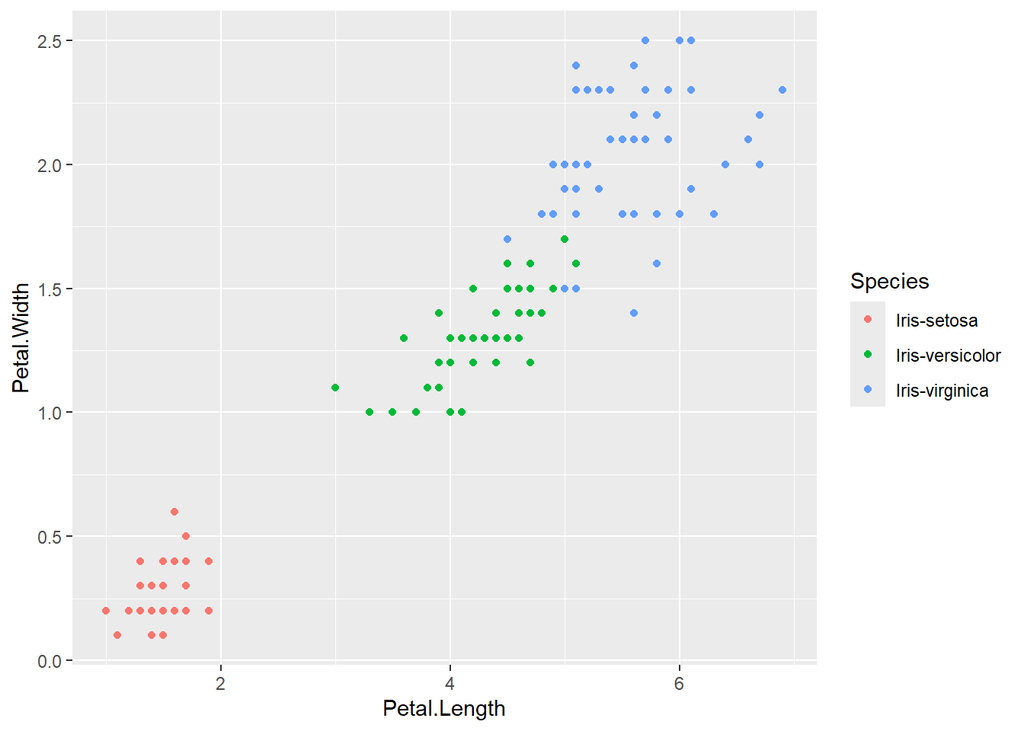

```r
ggplot(iris, aes(x=Petal.Length, y=Petal.Width, col = Species)) +
  geom_point()
```

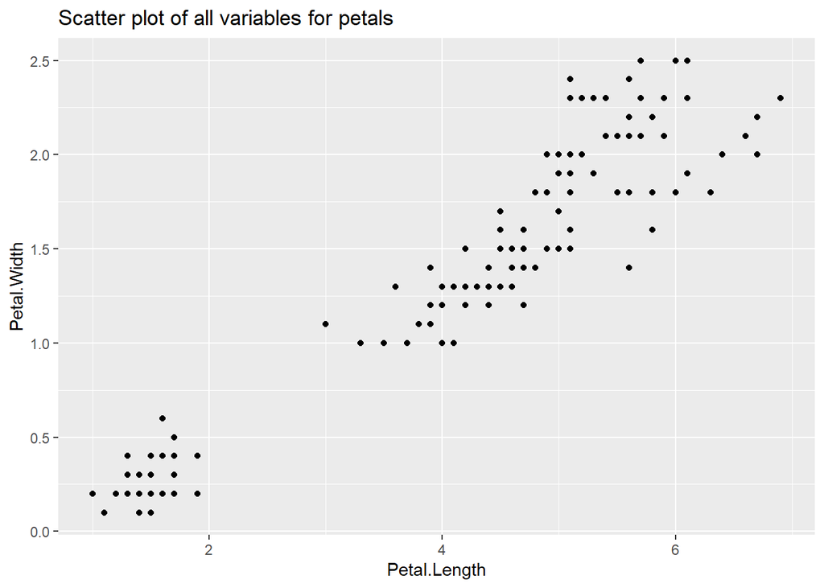

```r
ggplot(iris, aes(x=Petal.Length, y=Petal.Width)) +
  geom_point() +
  labs(title = "Scatter plot of all variables for petals")
```

```r
# Overall correlation `Petal.Length` and `Petal.Width`
cor(iris$Petal.Length, iris$Petal.Width)
```

```
## [1] 0.9627571
```

```r
# Return values of `iris` levels
x=levels(iris$Species)

cat("Print Setosa correlation matrix")
```

```
## Print Setosa correlation matrix
```

```r
print(x[1])
```

```r
cor(iris[iris$Species==x[1],1:4])
```

```
##              Sepal.Length Sepal.Width Petal.Length Petal.Width
## Sepal.Length           NA          NA           NA          NA
## Sepal.Width            NA          NA           NA          NA
## Petal.Length           NA          NA           NA          NA
## Petal.Width            NA          NA           NA          NA
```

```r
cat("Print Versicolor correlation matrix")
```

```
## Print Versicolor correlation matrix
```

```r
print(x[2])
```

```r
cor(iris[iris$Species==x[2],1:4])
```

```
##              Sepal.Length Sepal.Width Petal.Length Petal.Width
## Sepal.Length           NA          NA           NA          NA
## Sepal.Width            NA          NA           NA          NA
## Petal.Length           NA          NA           NA          NA
## Petal.Width            NA          NA           NA          NA
```

```r
cat("Print Virginica correlation matrix")
```

```
## Print Virginica correlation matrix
```

```r
print(x[3])
```

```r
cor(iris[iris$Species==x[3],1:4])
```

```
##              Sepal.Length Sepal.Width Petal.Length Petal.Width
## Sepal.Length           NA          NA           NA          NA
## Sepal.Width            NA          NA           NA          NA
## Petal.Length           NA          NA           NA          NA
## Petal.Width            NA          NA           NA          NA
```

Now, we will predict the species variable using KNN regression model. We can also normalize our dataset before doing the analysis.

```r
# create Normalize() function
normalize <- function(x) {
num <- x - min(x)
denom <- max(x) - min(x)
return (num/denom)
}

# Normalize the `iris` data
iris_norm <- as.data.frame(lapply(iris[1:4], normalize))

# Summarize
kable(summary(iris_norm),caption = "Summary of normalized iris data")
```

Summary of normalized iris data

|  | Sepal.Length | Sepal.Width | Petal.Length | Petal.Width |
| --- | --- | --- | --- | --- |
|  | Min. :0.0000 | Min. :0.0000 | Min. :0.0000 | Min. :0.00000 |
|  | 1st Qu.:0.2222 | 1st Qu.:0.3333 | 1st Qu.:0.1017 | 1st Qu.:0.08333 |
|  | Median :0.4167 | Median :0.4167 | Median :0.5678 | Median :0.50000 |
|  | Mean :0.4287 | Mean :0.4392 | Mean :0.4676 | Mean :0.45778 |
|  | 3rd Qu.:0.5833 | 3rd Qu.:0.5417 | 3rd Qu.:0.6949 | 3rd Qu.:0.70833 |
|  | Max. :1.0000 | Max. :1.0000 | Max. :1.0000 | Max. :1.00000 |

Now, we partition our data into test (33.33%) and training sets(66.66%).

```r
set.seed(54321)
ind <- sample(2, nrow(iris), replace=TRUE, prob=c(0.67, 0.33))

# Create training labels
iris.trainLabels <- iris[ind==1,5]

# Compose `iris` test labels
iris.testLabels <- iris[ind==2, 5]

# Now we can create the training and test datasets
# create training set
iris.training <- iris[ind==1, 1:4]

cat("Top 6 rows of training set")
```

```
## Top 6 rows of training set
```

```r
head(iris.training)
```

```
##   Sepal.Length Sepal.Width Petal.Length Petal.Width
## 1          5.1         3.5          1.4         0.2
## 2          4.9         3.0          1.4         0.2
## 3          4.7         3.2          1.3         0.2
## 4          4.6         3.1          1.5         0.2
## 5          5.0         3.6          1.4         0.2
## 7          4.6         3.4          1.4         0.3
```

```r
# Compose test set
iris.test <- iris[ind==2, 1:4]

cat("Top 6 rows of test set")
```

```
## Top 6 rows of test set
```

```r
head(iris.test)
```

```
##    Sepal.Length Sepal.Width Petal.Length Petal.Width
## 6           5.4         3.9          1.7         0.4
## 12          4.8         3.4          1.6         0.2
## 15          5.8         4.0          1.2         0.2
## 16          5.7         4.4          1.5         0.4
## 17          5.4         3.9          1.3         0.4
## 23          4.6         3.6          1.0         0.2
```

```r
library(gmodels)
library(class)
# Build the model
iris_pred <- knn(train = iris.training, test = iris.test, cl = iris.trainLabels, k=3)

# Put `iris.testLabels` in a data frame
irisTestLabels <- data.frame(iris.testLabels)

# Merge `iris_pred` and `iris.testLabels`
merge <- data.frame(iris_pred, iris.testLabels)

# Specify column names for `merge`
names(merge) <- c("Predicted Species", "Observed Species")
```

From the above analysis we can now check predicted and observed species:

```r
cat("First 6 rows of predicted and observed species using KNN")
```

```
## First 6 rows of predicted and observed species using KNN
```

```r
head(merge)
```

```
##   Predicted Species Observed Species
## 1       Iris-setosa      Iris-setosa
## 2       Iris-setosa      Iris-setosa
## 3       Iris-setosa      Iris-setosa
## 4       Iris-setosa      Iris-setosa
## 5       Iris-setosa      Iris-setosa
## 6       Iris-setosa      Iris-setosa
```

We can also use caret package to check the accuracy of this model:

```r
cm <- confusionMatrix(merge$`Predicted Species`, reference = as.factor(merge$`Observed Species`))
cm
```

```
## Confusion Matrix and Statistics
##
##                  Reference
## Prediction        Iris-setosa Iris-versicolor Iris-virginica
##   Iris-setosa              21               0              0
##   Iris-versicolor           0              15              1
##   Iris-virginica            0               0             16
##
## Overall Statistics
##
##                Accuracy : 0.9811
##                  95% CI : (0.8993, 0.9995)
##     No Information Rate : 0.3962
##     P-Value [Acc > NIR] : < 2.2e-16
##
##                   Kappa : 0.9714
##
##  Mcnemar's Test P-Value : NA
##
## Statistics by Class:
##
##                      Class: Iris-setosa Class: Iris-versicolor
## Sensitivity                      1.0000                 1.0000
## Specificity                      1.0000                 0.9737
## Pos Pred Value                   1.0000                 0.9375
## Neg Pred Value                   1.0000                 1.0000
## Prevalence                       0.3962                 0.2830
## Detection Rate                   0.3962                 0.2830
## Detection Prevalence             0.3962                 0.3019
## Balanced Accuracy                1.0000                 0.9868
##                      Class: Iris-virginica
## Sensitivity                         0.9412
## Specificity                         1.0000
## Pos Pred Value                      1.0000
## Neg Pred Value                      0.9730
## Prevalence                          0.3208
## Detection Rate                      0.3019
## Detection Prevalence                0.3019
## Balanced Accuracy                   0.9706
```

We can see that the model accuracy is pretty high here.

## Part 4

Suppose we collect data for a group of students in a statistics class with variables ${X1 =hours}$ studied, ${X2 =undergrad GPA}$, and ${Y =received A}$. We fit a logistic regression and produce estimated coefficient, $\hat{\beta}_0 = -6$, $\hat{\beta}_1 = 0.05$, $\hat{\beta}_2 = 1$.

Now, we will estimate the probability that a student who studies for 40 h and has an undergrad GPA of 3.5 gets an A in the class. For this question, we can simply plug in the beta values in this equation below:

$$\hat{p}(X) = \frac{e^{\hat\beta_0 +
\hat\beta_1 {X_1}}}{(1 + e^{\hat\beta_0 + \hat\beta_1
{X_1}})}$$

As:

$$\hat{p}(X) = \frac{e^{-6 + 0.05X_1 +
X_2}}{(1 + e^{-6 + 0.05X_1 + X_2})} = \frac{e^{-6 + 0.05*40 + 1*3.5}}{(1
+ e^{-6 + 0.05*40 + 1*3.5})} = 0.3775.$$

```r
cat("We can also write a function to calculate this and get the answer")
```

```
## We can also write a function to calculate this and get the answer
```

```r
calculate_prob <- function(x1,x2){ z <- exp(-6 + 0.05*x1 + 1*x2); return( round(z/(1+z),4))}
calculate_prob(40,3.5)
```

```
## [1] 0.3775
```

Next, we will check how many hours would the student need to study to have a 50% chance of getting an A in the class. The equation for predicted probability gives us:

$$\frac{e^{-6 + 0.05X_1 + 3.5}}{(1 + e^{-6
+ 0.05X_1 + 3.5})} = 0.5$$

from which, we get:

$$e^{-6 + 0.05X_1 + 3.5} = 1$$

If we take log of both sides, we get:

$$X_1 = \frac{2.5}{0.05} = 50$$

```r
cat("We can also use the function to calculate this and get the answer")
```

```
## We can also use the function to calculate this and get the answer
```

```r
hours <- seq(40,60,1)
probs <- mapply(hours, 3.5, FUN = calculate_prob)
names(probs) <- paste0(hours,"_hours")
probs
```

```
## 40_hours 41_hours 42_hours 43_hours 44_hours 45_hours 46_hours 47_hours
##   0.3775   0.3894   0.4013   0.4134   0.4256   0.4378   0.4502   0.4626
## 48_hours 49_hours 50_hours 51_hours 52_hours 53_hours 54_hours 55_hours
##   0.4750   0.4875   0.5000   0.5125   0.5250   0.5374   0.5498   0.5622
## 56_hours 57_hours 58_hours 59_hours 60_hours
##   0.5744   0.5866   0.5987   0.6106   0.6225
```

Hence, to have 50 percent chance for securing A, the student has to study for 50 hours.

Suppose, we wish to predict whether a given stock will issue a dividend this year (“Yes” or “No”) based on $X$, last year’s percent profit. We examine a large number of companies and discover that the mean value of $X$ for companies that issued a dividend was $\overline{X} = 10$, while the mean for those that didn’t was $\overline{X} = 0$. In addition, the variance of X for these two sets of companies was $\hat{\sigma}^2 = 36$. Finally, 80% of companies issued dividends. Assuming that $X$ follows a normal distribution, predict the probability that a company will issue a dividend this year given that its percentage profit was $X = 4$ last year.

Recall that the density function for a normal random variable is
$$f(x) =
\frac{1}{\sqrt{2\pi\sigma^2}}e^{\frac{-(x-\mu)^2}{2\sigma^2}}$$
. You will need to use Bayes’ theorem.

For this question, we have to plugin the normal density into Bayes’ theorem, prior probability for ‘yes’ is given, and next do math as shown in the code below:

Based on pdf and Bayes theorem, we have:

$$p_k(X) = \frac{\pi_k
\frac{1}{\sqrt{2\pi}\sigma} exp \bigg( {-\frac{1}{2\sigma^2}(x -
\mu_k)^2} \bigg)}
{\sum _{l=1}^{k}\pi_l\frac{1}{\sqrt{2\pi}\sigma} exp \bigg(
{-\frac{1}{2\sigma^2}(x - \mu_l)^2} \bigg)}$$

If we just plug in the values for:

$$\pi _{YES} = 0.8, \pi _{NO} = 0.2, \mu
_{YES} = 10, \mu _{N0} = 0, \widehat{\sigma^2} = 36$$

We have,

$$f _{YES}(4) = 0.04033, \ f _{NO}(4) =
0.05324$$

$$pYES(4) = \frac{0.8 \times 0.04033}{0.8
\times 0.04033 + 0.2 \times 0.05324} = 0.75186$$

The same can be done in R to get the result:

```r
# pdf function
pdf <- function(x, mu_k, sigma){((sqrt(2*pi)*sigma)^-1)*(exp(-((2*sigma^2)^-1)*(x-mu_k)^2))}

sigma <- 6 # for both classes

# Type 1 where companies issued dividend
pi_1 <- .8
mu_1 <- 10

# Type 2 where companies  did not issue dividend
pi_2 <- .2
mu_2 <- 0

# Calculate probabilities based on Bayes
x <- 4
p_1 <- (pi_1*pdf(4,mu_1,sigma))/(pi_1*pdf(4,mu_1,sigma) + pi_2*pdf(4,mu_2,sigma))
p_2 <- (pi_2*pdf(4,mu_2,sigma))/(pi_1*pdf(4,mu_1,sigma) + pi_2*pdf(4,mu_2,sigma))

# rounding the numbers
p_1 <- round(p_1,4)
p_2 <- round(p_2,4)

# prediction
prediction <- data.frame(cbind(c("Dividend", "Non-Dividend"), c(p_1, p_2)))
colnames(prediction) <- c("Types", "prediction")
prediction
```

```
##          Types prediction
## 1     Dividend     0.7519
## 2 Non-Dividend     0.2481
```

Based on this analysis, 75.19 percent of the companies will issue dividend this year and 24.81% of the companies will not.

Now, we will fit a model using the predictors (chosen previously in this exercise) for classification using the `MclustDA` function from the `mclust-package`. We will first get the summary of our model. We will also find the best model selected by BIC and report the Model Name and the BIC. (See https://www.rdocumentation.org/packages/mclust/versions/5.4/topics/mclustModelNames)

We will also report on the training error, test error, and true positive and true negative rates.

```r
library(ISLR)
library(mclust)
data(Weekly)
cat("Omitting the `Today` variable")
```

```
## Omitting the `Today` variable
```

```r
wk=Weekly[,-8]
index=c(which(Weekly$Year==2009), which(Weekly$Year==2010))
train=wk[-index,]
test=wk[index,]

cat("Just with lag 2")
```

```
## Just with lag 2
```

```r
X=as.data.frame(train[,3]) ## keeping only Lag2
class=train$Direction

cat("MclustDA")
```

```
## MclustDA
```

```r
mod1 = MclustDA(X, class)
summary(mod1)
```

```
## ------------------------------------------------
## Gaussian finite mixture model for classification
## ------------------------------------------------
##
## MclustDA model summary:
##
##  log-likelihood   n df       BIC
##       -2129.439 985 10 -4327.804
##
## Classes   n     % Model G
##    Down 441 44.77     V 2
##    Up   544 55.23     V 2
##
## Training confusion matrix:
##       Predicted
## Class  Down  Up
##   Down   76 365
##   Up     70 474
## Classification error = 0.4416
## Brier score          = 0.2452
```

```r
cat("train error")
```

```
## train error
```

```r
predstrain=predict(mod1, newdata=train[,3])$classification
###################################################################
cat("function to get overall accuracy, TPR and TNR")
```

```
## function to get overall accuracy, TPR and TNR
```

```r
overall_accuracy_TPR_TNR=function(con){
  OA=round(100*(con[1,1]+con[2,2])/sum(con),2) ## error rate is 100-OA
  TPR=round(con[2,2]/(con[2,2]+con[1,2])*100,2)
  TNR=round(con[1,1]/(con[1,1]+con[2,1])*100,2) ## FPR=100-TNR
  return(list(overall_accuracy = OA,True_positive_rate = TPR,True_negative_rate = TNR))
}
###################################################################

overall_accuracy_TPR_TNR(table(predstrain,class))
```

```
## $overall_accuracy
## [1] 55.84
##
## $True_positive_rate
## [1] 87.13
##
## $True_negative_rate
## [1] 17.23
```

```r
cat("test error")
```

```
## test error
```

```r
predstest=predict(mod1, newdata=test[,3])$classification
trueClass=test[,8]
overall_accuracy_TPR_TNR(table(predstest,trueClass))
```

```
## $overall_accuracy
## [1] 54.81
##
## $True_positive_rate
## [1] 85.25
##
## $True_negative_rate
## [1] 11.63
```

```r
cat("With all the variables")
```

```
## With all the variables
```

```r
X=as.data.frame(train[,-8]) ## keeping only Lag2
mod11 = MclustDA(X, class)
summary(mod11)
```

```
## ------------------------------------------------
## Gaussian finite mixture model for classification
## ------------------------------------------------
##
## MclustDA model summary:
##
##  log-likelihood   n  df       BIC
##       -12477.54 985 286 -26926.37
##
## Classes   n     % Model G
##    Down 441 44.77   VVV 4
##    Up   544 55.23   VVV 4
##
## Training confusion matrix:
##       Predicted
## Class  Down  Up
##   Down  251 190
##   Up    160 384
## Classification error = 0.3553
## Brier score          = 0.2177
```

```r
predstrain=predict(mod11, newdata=train[,-8])$classification
overall_accuracy_TPR_TNR(table(predstrain,class))
```

```
## $overall_accuracy
## [1] 64.47
##
## $True_positive_rate
## [1] 70.59
##
## $True_negative_rate
## [1] 56.92
```

```r
predstest=predict(mod11, newdata=test[,-8])$classification
trueClass=test[,8]
overall_accuracy_TPR_TNR(table(predstest,trueClass))
```

```
## $overall_accuracy
## [1] 53.85
##
## $True_positive_rate
## [1] 85.25
##
## $True_negative_rate
## [1] 9.3
```

As we wanted to test, I fitted a model with the `MclustDA` function. The dataset was partitioned into training and testing sets using the same criterion as before:

Two models were fitted. One with just the variable `Lag2`, and in the other one, `all` the variables were used. As we can see from the above table, in the univariate case (with lag2 variable), the best model was a two-component model in each class, having variable variance.